# Practical Machine Learning Project

Produced by B. Ladouceur

September 5, 2018

# Introduction

The Internet of Things (IoT) is vastly increasing the amount of sensors and are producing vast quantity of data on a wide variety of systems. Devices such as the Jawbone Up, Nike FuelBand and Fitbit gather data on human beings, for example on their physical activities. In sports, proper form is often more important than the amount of repetitions, yet this is not often looked at by analysis. The intention of this project is to find a forecasting method that will enable us to predict the way a barbell weight will be lifted. It is possible to find more information on the dataset from the following website: http://groupware.les.inf.puc-rio.br/har (section on Weight Lifting Exercise).

The first step of the analysis will be to load the required data as well as to exmine the dimensions as well as the structure.

```r
#Loading Libraries
library(caret);library(rpart.plot);library(rattle); library(dplyr);library(e1071);library(caTools)
#Data load
Train <- read.csv(url("https://d396qusza40orc.cloudfront.net/predmachlearn/pml-training.csv"),header=TRUE)
dim(Train)
```

```
## [1] 19622   160
```

```r
Test <- read.csv(url("https://d396qusza40orc.cloudfront.net/predmachlearn/pml-testing.csv"),header=TRUE)
dim(Test)
```

```
## [1]  20 160
```

```r
str(Train)
```

```
## 'data.frame':    19622 obs. of  160 variables:
##  $ X                       : int  1 2 3 4 5 6 7 8 9 10 ...
##  $ user_name               : Factor w/ 6 levels "adelmo","carlitos",..: 2 2 2 2 2 2 2 2 2 2 ...
##  $ raw_timestamp_part_1    : int  1323084231 1323084231 1323084231 1323084232 1323084232 1323084232 1323084232 1323084232 1323084232 1323084232 ...
##  $ raw_timestamp_part_2    : int  788290 808298 820366 120339 196328 304277 368296 440390 484323 484434 ...
##  $ cvtd_timestamp          : Factor w/ 20 levels "02/12/2011 13:32",..: 9 9 9 9 9 9 9 9 9 9 ...
##  $ new_window              : Factor w/ 2 levels "no","yes": 1 1 1 1 1 1 1 1 1 1 ...
##  $ num_window              : int  11 11 11 12 12 12 12 12 12 12 ...
##  $ roll_belt               : num  1.41 1.41 1.42 1.48 1.48 1.45 1.42 1.42 1.43 1.45 ...
##  $ pitch_belt              : num  8.07 8.07 8.07 8.05 8.07 8.06 8.09 8.13 8.16 8.17 ...
##  $ yaw_belt                : num  -94.4 -94.4 -94.4 -94.4 -94.4 -94.4 -94.4 -94.4 -94.4 -94.4 ...
##  $ total_accel_belt        : int  3 3 3 3 3 3 3 3 3 3 ...
##  $ kurtosis_roll_belt      : Factor w/ 397 levels "","-0.016850",..: 1 1 1 1 1 1 1 1 1 1 ...
##  $ kurtosis_picth_belt     : Factor w/ 317 levels "","-0.021887",..: 1 1 1 1 1 1 1 1 1 1 ...
##  $ kurtosis_yaw_belt       : Factor w/ 2 levels "","#DIV/0!": 1 1 1 1 1 1 1 1 1 1 ...
```

[output cut: 86 more lines]

## Data Preprocessing

The pml-training.csv dataset has 19622 cases of 160 variables, while the pml-testing.csv file only has 20 cases with the same variables. We will need to first select which variables should be used within the various models that will be tested. AS we take a look at the dataset, we can observe that many variables have a huge proportion of NAs, which could be a distraction. Some columns could also have very little predictive power, like the first seven whch includes identification of people. We will remove them as well.

```r
# Remove variables with more than 95% NAs
TrainVarRemoved <- which(colSums(is.na(Train) | Train=="")>0.95*dim(Train)[1])
TrainCut <- Train[,-TrainVarRemoved]
TrainCut <- TrainCut[,-c(1:7)]
dim(TrainCut)
```

```
## [1] 19622    53
```

```r
# We do the same for the test set

TestCut <- Test[,c("roll_belt","pitch_belt","yaw_belt","total_accel_belt","gyros_belt_x",
"gyros_belt_y","gyros_belt_z","accel_belt_x","accel_belt_y","accel_belt_z",
"magnet_belt_x","magnet_belt_y","magnet_belt_z","roll_arm","pitch_arm",
"yaw_arm","total_accel_arm","gyros_arm_x","gyros_arm_y","gyros_arm_z",
"accel_arm_x","accel_arm_y","accel_arm_z","magnet_arm_x","magnet_arm_y",
"magnet_arm_z","roll_dumbbell","pitch_dumbbell","yaw_dumbbell","total_accel_dumbbell",
"gyros_dumbbell_x","gyros_dumbbell_y","gyros_dumbbell_z","accel_dumbbell_x","accel_dumbbell_y",
"accel_dumbbell_z","magnet_dumbbell_x","magnet_dumbbell_y","magnet_dumbbell_z","roll_forearm","pitch_forearm","yaw_forearm","total_accel_forearm","gyros_forearm_x","gyros_forearm_y",
"gyros_forearm_z","accel_forearm_x","accel_forearm_y","accel_forearm_z","magnet_forearm_x",
"magnet_forearm_y","magnet_forearm_z")]


dim(TestCut)
```

```
## [1] 20 52
```

```r
length(colnames(TestCut))
```

```
## [1] 52
```

```r
dim(TrainCut)
```

```
## [1] 19622    53
```

```r
length(colnames(TrainCut))
```

```
## [1] 53
```

The TrainCut dataset has only 52 independent variables and 1 dependent variable. Since we don’t have the **classe** variable in the TestCut set, we only have have the 52 independent variables. As we cannot use the TestCut set for validation, we will need to separate the training set in 2.

```r
set.seed(00001)
inTrain1 <- createDataPartition(TrainCut$classe, p=0.75, list=FALSE)
Train1 <- TrainCut[inTrain1,]
Test1 <- TrainCut[-inTrain1,]
dim(Train1)
```

```
## [1] 14718    53
```

```r
dim(Test1)
```

```
## [1] 4904   53
```

For this projet, we will compare 4 forecasting methods, 3 of which were part of the class, which are *Classification Tree*, *Random Forest* and *Gradient Boosting*, in the order they were shown during the lectures. The fourth model that will be tried will be a *Principal Component Analysis coupled with a Support Vector Machine*. To deal with overfitting, a 10 fold cross-validation will be used.

## Classification Tree

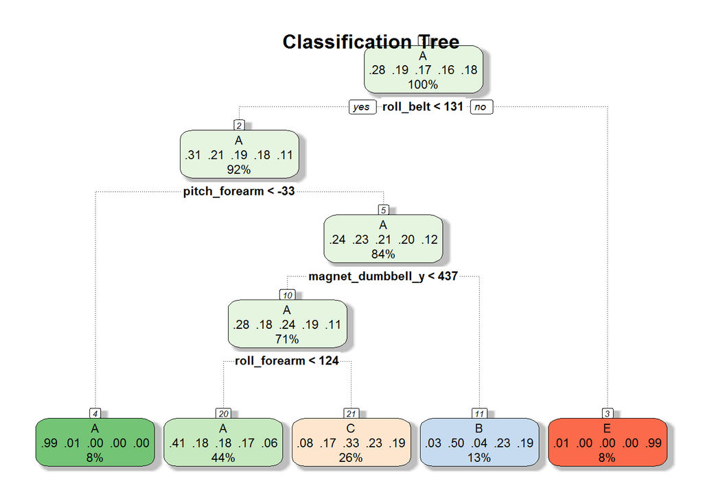

```r
# First model Classification tree
cv <- trainControl(method="cv", number=10)
modelClassificationTree <- train(classe~., data=Train1, method="rpart", trControl=cv)
fancyRpartPlot(modelClassificationTree$finalModel, main="Classification Tree", sub=NULL)
```

```r
#prp(modelClassificationTree,main = "default prp\n(type = 0, extra = 0)")
trainforecast <- predict(modelClassificationTree,newdata=Test1)
confMatCT <- confusionMatrix(Test1$classe,trainforecast)
confMatCT$table
```

```
##           Reference
## Prediction    A    B    C    D    E
##          A 1260   28  102    0    5
##          B  387  326  236    0    0
##          C  402   24  429    0    0
##          D  348  140  316    0    0
##          E  114  118  225    0  444
```

```r
AccuCT <- confMatCT$overall[1]
OOSE_CT <- 1-AccuCT
```

We can notice that the accuracy of this first model is not bad at 0.5014274 with a predicted out of sample error of 0.4985726, which is better than randomly guessing but still not very high. This means that variable classe will not be predicted very well by the other predictors. So let’s take a look at another tool, the random forest which should be more powerful at the cost of some interpretability.

## Random Forest

```r
model_RandomForest <- train(classe~., data=Train1, method="rf", trControl=cv, verbose=FALSE)
print(model_RandomForest)
```

```
## Random Forest
##
## 14718 samples
##    52 predictor
##     5 classes: 'A', 'B', 'C', 'D', 'E'
##
## No pre-processing
## Resampling: Cross-Validated (10 fold)
## Summary of sample sizes: 13247, 13246, 13244, 13247, 13246, 13247, ...
## Resampling results across tuning parameters:
##
##   mtry  Accuracy   Kappa
##    2    0.9930695  0.9912330
##   27    0.9932050  0.9914046
##   52    0.9871582  0.9837550
##
## Accuracy was used to select the optimal model using the largest value.
## The final value used for the model was mtry = 27.
```

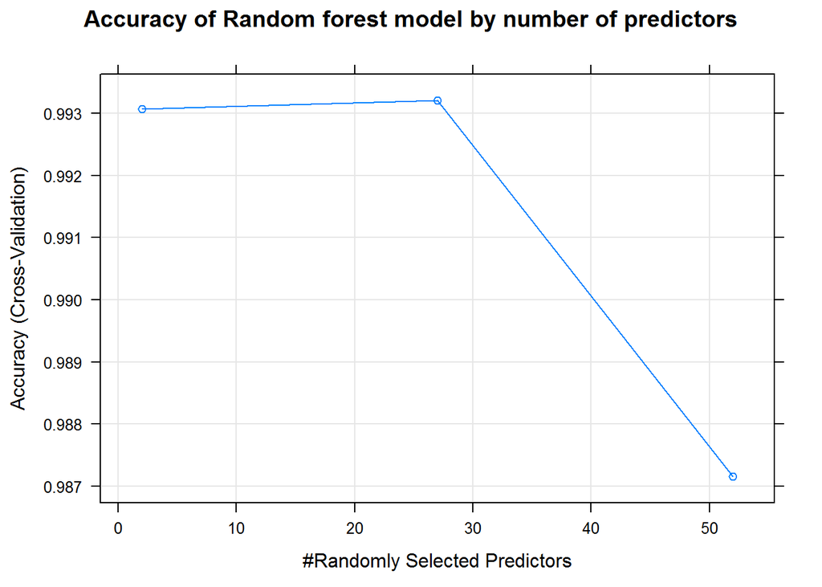

```r
plot(model_RandomForest,main="Accuracy of Random forest model by number of predictors")
```

```r
trainpred <- predict(model_RandomForest,newdata=Test1)
confMatRF <- confusionMatrix(Test1$classe,trainpred)
confMatRF$table
```

```
##           Reference
## Prediction    A    B    C    D    E
##          A 1390    2    2    0    1
##          B    4  943    2    0    0
##          C    0    3  850    2    0
##          D    0    1    7  795    1
##          E    0    0    0    3  898
```

```r
AccuRF <- confMatRF$overall[1]
AccuRF
```

```
##  Accuracy
## 0.9942904
```

```r
OOSE_RF <- 1-AccuRF
names(model_RandomForest$finalModel)
```

```
##  [1] "call"            "type"            "predicted"
##  [4] "err.rate"        "confusion"       "votes"
##  [7] "oob.times"       "classes"         "importance"
## [10] "importanceSD"    "localImportance" "proximity"
## [13] "ntree"           "mtry"            "forest"
## [16] "y"               "test"            "inbag"
## [19] "xNames"          "problemType"     "tuneValue"
## [22] "obsLevels"       "param"
```

```r
model_RandomForest$finalModel$classes
```

```
## [1] "A" "B" "C" "D" "E"
```

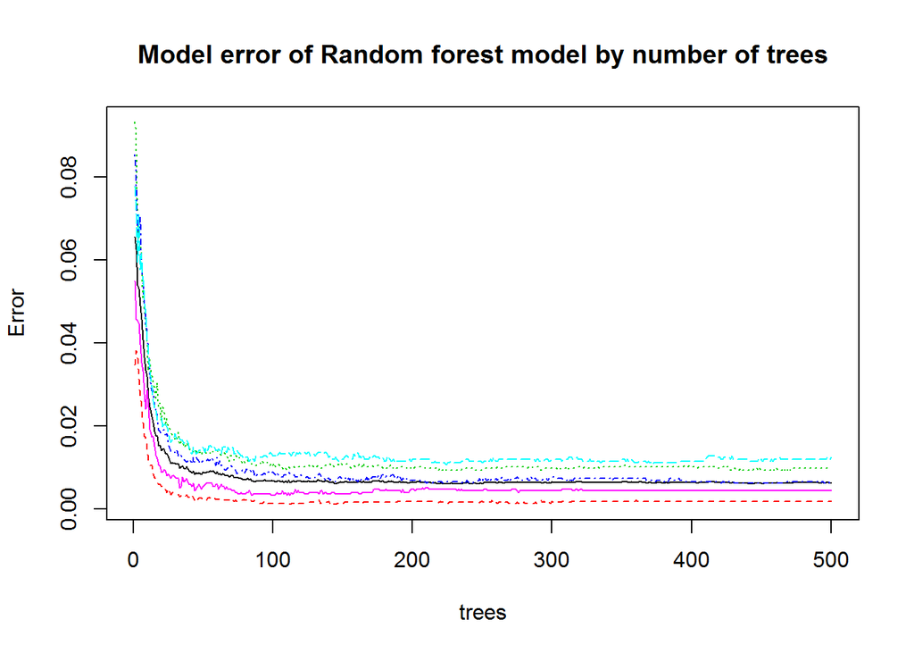

```r
plot(model_RandomForest$finalModel,main="Model error of Random forest model by number of trees")
```

```r
MostImpVars <- varImp(model_RandomForest)
MostImpVars
```

```
## rf variable importance
##
##   only 20 most important variables shown (out of 52)
##
##                      Overall
## roll_belt             100.00
## pitch_forearm          60.89
## yaw_belt               55.69
## pitch_belt             43.76
## magnet_dumbbell_z      43.76
## magnet_dumbbell_y      43.12
## roll_forearm           42.97
## accel_dumbbell_y       23.44
## roll_dumbbell          17.54
## accel_forearm_x        16.89
## magnet_dumbbell_x      16.29
## magnet_belt_z          15.03
## magnet_forearm_z       14.61
## accel_dumbbell_z       13.81
## total_accel_dumbbell   13.50
## accel_belt_z           12.90
## magnet_belt_y          12.82
## gyros_belt_z           11.53
## magnet_belt_x          10.45
## yaw_arm                10.08
```

With random forest, we reach an accuracy of 0.9942904 using 10 folds cross-validation, which is an excellent result (forecasted Out of Sample Error of 0.0057096. Let’s try another strong method, which is gradient boosting.

## Gradient Boosting

```r
model_GradientBoosting <- train(classe~., data=Train1, method="gbm", trControl=cv, verbose=FALSE)
print(model_GradientBoosting)
```

```
## Stochastic Gradient Boosting
##
## 14718 samples
##    52 predictor
##     5 classes: 'A', 'B', 'C', 'D', 'E'
##
## No pre-processing
## Resampling: Cross-Validated (10 fold)
## Summary of sample sizes: 13247, 13247, 13245, 13247, 13246, 13247, ...
## Resampling results across tuning parameters:
##
##   interaction.depth  n.trees  Accuracy   Kappa
##   1                   50      0.7524112  0.6859233
##   1                  100      0.8219882  0.7747175
##   1                  150      0.8532435  0.8142770
##   2                   50      0.8563008  0.8178646
##   2                  100      0.9062412  0.8813401
##   2                  150      0.9324661  0.9145338
##   3                   50      0.8980178  0.8708921
##   3                  100      0.9430645  0.9279510
##   3                  150      0.9612731  0.9509989
##
## Tuning parameter 'shrinkage' was held constant at a value of 0.1
##
## Tuning parameter 'n.minobsinnode' was held constant at a value of 10
## Accuracy was used to select the optimal model using the largest value.
## The final values used for the model were n.trees = 150,
##  interaction.depth = 3, shrinkage = 0.1 and n.minobsinnode = 10.
```

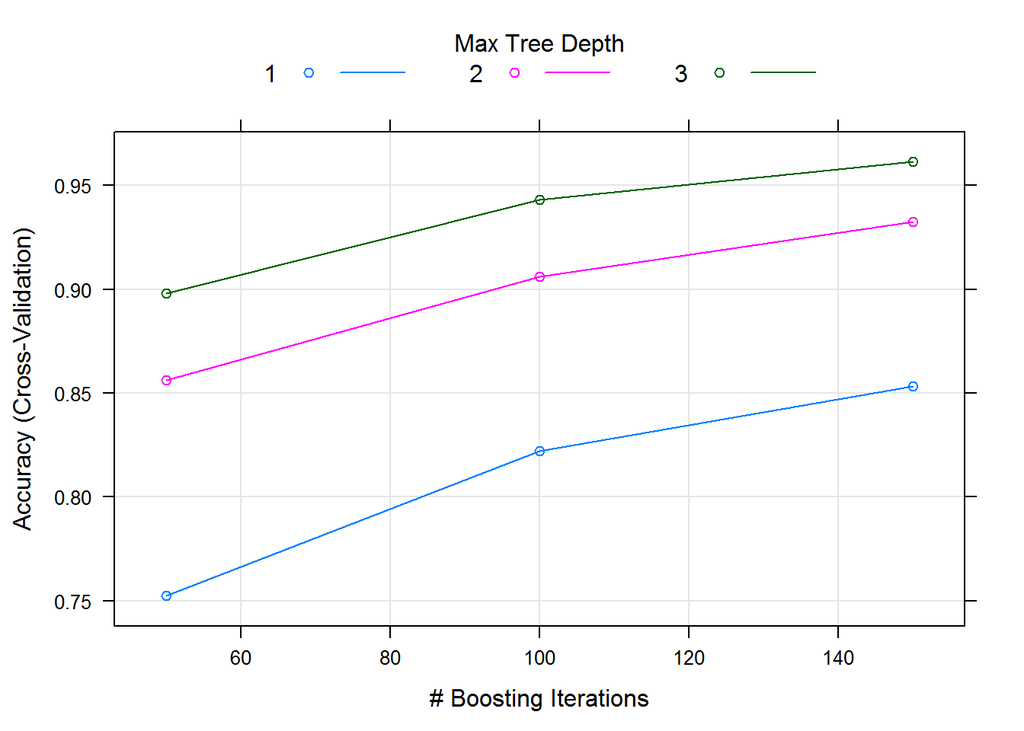

```r
plot(model_GradientBoosting)
```

```r
trainpred <- predict(model_GradientBoosting,newdata=Test1)
confMatGBM <- confusionMatrix(Test1$classe,trainpred)
confMatGBM$table
```

```
##           Reference
## Prediction    A    B    C    D    E
##          A 1365   16    5    4    5
##          B   28  905   16    0    0
##          C    0   29  810   15    1
##          D    0    4   20  772    8
##          E    1    9    6   15  870
```

```r
AccuGB <- confMatGBM$overall[1]
OOSE_GB <- 1 - AccuGB
```

Precision with 10 folds we reach an accuracy of 0.9628874, which is very strong but less accurate than the random forest (forecasted out of sample error of 0.0371126. Let’s try another methodology, which is the Support Vector Machine, following a PCA.

## PCA followed by a SVM

```r
training_set = Train1
test_set = Test1
pca = preProcess(x = training_set[-53], method = 'pca', pcaComp = 2)
training_set = predict(pca, training_set)
training_set = training_set[c(2, 3, 1)]
test_set = predict(pca, test_set)
test_set = test_set[c(2, 3, 1)]
# Fitting SVM to the Training set
library(e1071)
classifier = svm(formula = classe ~ .,
                 data = training_set,
                 type = 'nu-classification',
                 kernel = 'linear')

# Predicting the Test set results
y_pred = predict(classifier, newdata = test_set[-3])
# Making the Confusion Matrix
cm = table(test_set[,3], y_pred)
cm
```

```
##    y_pred
##       A   B   C   D   E
##   A 370   0 259 618 148
##   B 257   1 268 302 121
##   C 279   0 211 259 106
##   D 253   0 175 233 143
##   E 356   2 189 215 139
```

```r
AccSvm <- (cm[1,1] + cm[2,2] + cm[3,3] + cm[4,4] + cm[5,5])/sum(cm)*100
```

# Conclusion

Of the tools we’ve been using in this project, random forest proved to be the most accurate. As such, this is the model that will be applied to the 20 observations dataset in order to conduct the last forecasting. Another option could have been to build a neural network, but the accuracy of the random forest is already very high so we will apply it to the 20 cases we need to predict.

```r
LastPred <- predict(model_RandomForest,newdata=TestCut)
LastPred
```

```
##  [1] B A B A A E D B A A B C B A E E A B B B
## Levels: A B C D E
```

Thank you for reading this far, one more course and a Capstone to go, keep it up!